# The Linear Regression Model

Part I — Introduction & OLS Estimation

Paulo Fagandini

Lisbon Accounting and Business School — Polytechnic University of Lisbon

# The Linear Regression Model

## Lecture Overview

**Lecture 8 — Introduction & OLS Estimation**

- Why regression? Motivation and examples
- Statistical vs. deterministic relationships
- Scatter diagrams and linear correlation
- The Simple Linear Regression (SLR) model
- The Classical Assumptions (Gauss–Markov)
- OLS: deriving $\hat{\beta}_0$ and $\hat{\beta}_1$
- Interpreting the estimated coefficients
- Running a regression in R with `lm()`

**Note**

**Reference:** Newbold, Carlson & Thorne — *Statistics for Business and Economics*, Chapters 11–12.

# Why Regression?

## Motivation

In many situations, we observe that variables tend to **move together**:

**Accounting & Finance**

- Sales revenue → Operating profit
- Advertising spend → Market share
- Firm leverage → Cost of debt
- Total assets → Audit fees

**Economics & Management**

- Disposable income → Consumption
- Interest rates → Investment
- Education → Earnings
- Hours studied → Exam grade

**Regression analysis** lets us:

1. **Describe** the average relationship between variables
2. **Quantify** the size of that relationship
3. **Predict** values of one variable from another

## Statistical vs. Deterministic Relationships

**Deterministic:**
$$C = 2\pi r$$

Every value of $r$ gives **exactly one** $C$.

No randomness. No need for statistics.

**Statistical:**
$$\text{Profit}_i = \beta_0 + \beta_1\,\text{Revenue}_i + \varepsilon_i$$

Same revenue $\rightarrow$ **different** profit across firms.

The error $\varepsilon_i$ captures everything else.

**Important**

Regression models the **conditional mean** of $Y$ given $X$:

$$E[Y \mid X = x] = \beta_0 + \beta_1\,x$$

We do **not** claim $X$ determines $Y$ exactly — only **on average**.

## Types of Variables

| Role | Name | Also called | Symbol |
| --- | --- | --- | --- |
| What we explain | **Dependent variable** | Response, regressand | $Y$ |
| What explains it | **Independent variable** | Regressor, predictor | $X$ |

- $Y$ is always **quantitative**.
- $X$ can be quantitative or qualitative (dummy variables — introduced in Part II).

**Running example (hypothetical data throughout):**

> *A firm’s operating profit ($Y$, m.u.) as a function of sales revenue ($X$, m.u.).*

**Note**

All numerical examples use **hypothetical data** constructed for illustration purposes only.

# Exploring the Relationship

## The Scatter Diagram

Before fitting any model, always **plot the data**. The scatter diagram displays the $n$ observed pairs $(x_i, y_i)$.

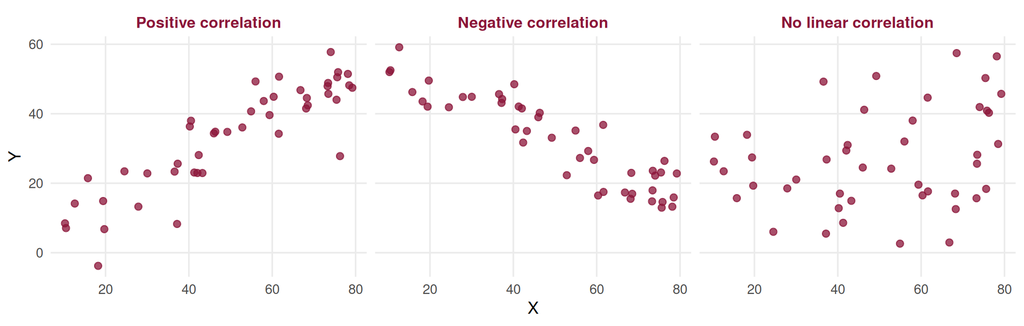

## Reading the Scatter Diagram

From the scatter diagram we assess:

- **Direction:** positive (both increase together) or negative (one increases, the other decreases)?
- **Form:** linear, curved, or no discernible pattern?
- **Strength:** how tightly do points cluster around the trend?
- **Outliers:** any unusual observations that break the pattern?

**Important**

**Always plot before you fit.**

A high $R^2$ on a non-linear or structurally misspecified relationship can be meaningless. Classic illustration: **Anscombe’s Quartet.**

## Anscombe’s Quartet

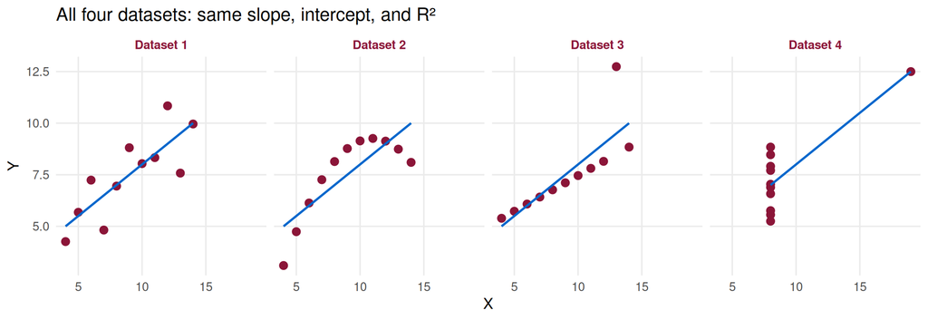

$\hat{\beta}_0 \approx 3.0$, $\hat{\beta}_1 \approx 0.50$, $R^2 \approx 0.67$ for **all four** — but only Dataset 1 works.

# The SLR Model

## Model Specification

The **Simple Linear Regression (SLR)** model:

$$\boxed{Y_i = \beta_0 + \beta_1 X_i + \varepsilon_i, \qquad i = 1, 2, \ldots, n}$$

| Symbol | Name | Meaning |
| --- | --- | --- |
| $Y_i$ | Dependent variable | Observed outcome for unit $i$ |
| $X_i$ | Independent variable | Known regressor for unit $i$ |
| $\beta_0$ | Intercept | Mean of $Y$ when $X = 0$ |
| $\beta_1$ | Slope | Change in mean $Y$ per unit increase in $X$ |
| $\varepsilon_i$ | Error term | All other factors affecting $Y_i$ |

**Note**

$\beta_0$ and $\beta_1$ are **unknown population parameters**. Our goal is to estimate them from data as $\hat{\beta}_0$ and $\hat{\beta}_1$.

## The Error Term $\varepsilon_i$

$$Y_i = \underbrace{\beta_0 + \beta_1 X_i}_{\text{systematic part}} + \underbrace{\varepsilon_i}_{\text{random part}}$$

The error captures:

- **Omitted variables** — factors that influence $Y$ but are not in the model
- **Measurement error** — imprecision in recording $Y_i$ or $X_i$
- **Inherent randomness** — unpredictable variation in behaviour or outcomes

**Important**

The error is **not a mistake** in the model — it is an unavoidable feature of any statistical relationship. What matters is that we make appropriate assumptions about its behaviour.

# The Classical Assumptions

## Gauss–Markov Assumptions

For OLS to have good statistical properties, we require:

| # | Name | Statement |
| --- | --- | --- |
| **A1** | Linearity | $Y_i = \beta_0 + \beta_1 X_i + \varepsilon_i$ |
| **A2** | Zero mean | $E[\varepsilon_i] = 0 \;\forall\, i$ |
| **A3** | Homoscedasticity | $\text{Var}(\varepsilon_i) = \sigma^2 \;\forall\, i$ |
| **A4** | No autocorrelation | $\text{Cov}(\varepsilon_i, \varepsilon_j) = 0 \;\forall\, i \neq j$ |
| **A5** | Exogeneity | $X_i$ is fixed or independent of $\varepsilon_i$ |
| **A6** | Normality | $\varepsilon_i \sim N(0,\, \sigma^2)$ |

**Note**

**A1–A5** are the Gauss–Markov conditions. Under them, OLS is **BLUE** (Best Linear Unbiased Estimator). **A6** is additionally required for exact $t$- and $F$-tests in small samples.

## What the Assumptions Imply

Under A1–A6, for each $i$:

$$Y_i \mid X_i \;\sim\; N\!\left(\beta_0 + \beta_1 X_i,\; \sigma^2\right)$$

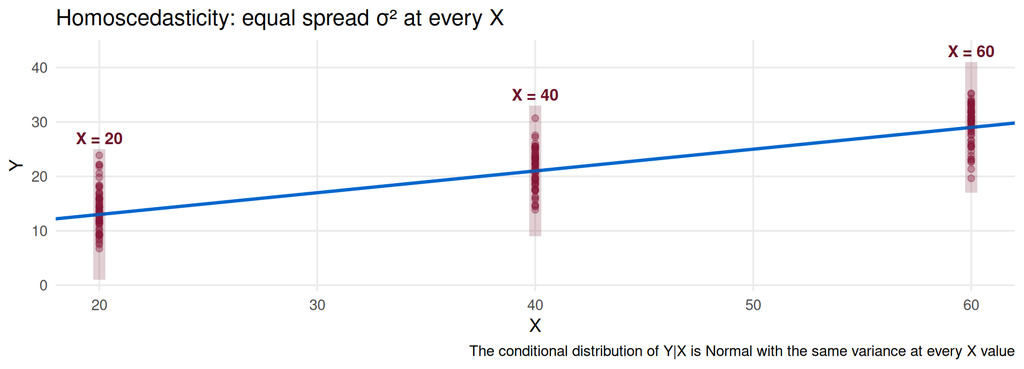

# OLS Estimation

## The Idea: Minimise Squared Residuals

Given data $(x_1,y_1),\ldots,(x_n,y_n)$, the **fitted line** is:

$$\hat{Y}_i = \hat{\beta}_0 + \hat{\beta}_1 X_i$$

The **residual** for observation $i$:

$$e_i = Y_i - \hat{Y}_i$$

**Important**

**Ordinary Least Squares (OLS):** choose $\hat{\beta}_0$ and $\hat{\beta}_1$ to minimise the **Sum of Squared Residuals**:

$$\min_{\hat{\beta}_0,\,\hat{\beta}_1} \;\text{SSR} = \sum_{i=1}^{n} e_i^2 = \sum_{i=1}^{n}(Y_i - \hat{\beta}_0 - \hat{\beta}_1 X_i)^2$$

Why **square** the residuals? To penalise large errors symmetrically and to obtain a unique closed-form solution.

## OLS: Visualising the Criterion

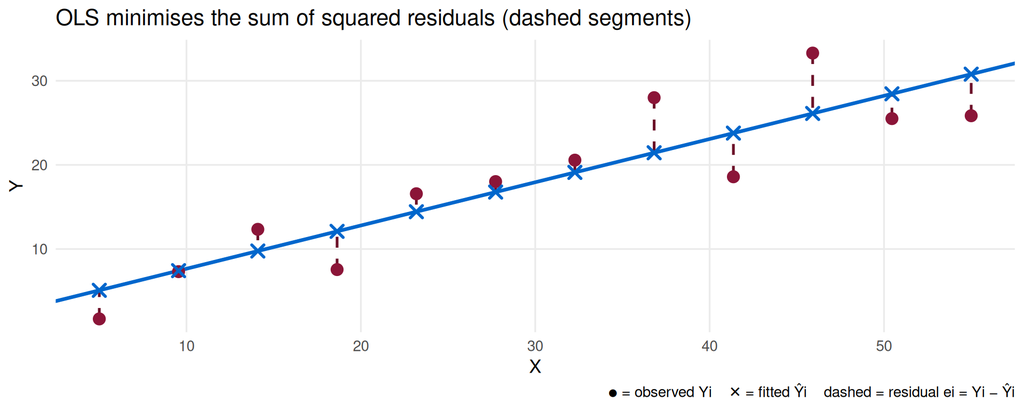

## OLS Formulas

Taking partial derivatives of SSR and setting them to zero yields:

$$\boxed{\hat{\beta}_1 = \frac{\displaystyle\sum_{i=1}^{n}(X_i - \bar{X})(Y_i - \bar{Y})}{\displaystyle\sum_{i=1}^{n}(X_i - \bar{X})^2} = \frac{S_{XY}}{S_{XX}}}$$

$$\boxed{\hat{\beta}_0 = \bar{Y} - \hat{\beta}_1\,\bar{X}}$$

where $S_{XY} = \sum(X_i-\bar{X})(Y_i-\bar{Y})$ and $S_{XX} = \sum(X_i-\bar{X})^2$.

**Note**

Since $\hat{\beta}_0 = \bar{Y} - \hat{\beta}_1\bar{X}$, the fitted line **always passes through** $(\bar{X},\,\bar{Y})$.

## Deriving the OLS Formulas

Minimise $\text{SSR} = \sum(Y_i - \beta_0 - \beta_1 X_i)^2$:

$$\frac{\partial\,\text{SSR}}{\partial \beta_0} = -2\sum(Y_i - \beta_0 - \beta_1 X_i) = 0$$

$$\frac{\partial\,\text{SSR}}{\partial \beta_1} = -2\sum X_i(Y_i - \beta_0 - \beta_1 X_i) = 0$$

These are the **Normal Equations**:

$$\sum Y_i = n\hat{\beta}_0 + \hat{\beta}_1 \sum X_i$$

$$\sum X_i Y_i = \hat{\beta}_0 \sum X_i + \hat{\beta}_1 \sum X_i^2$$

Solving simultaneously gives the formulas on the previous slide.

# Interpreting the Estimates

## Interpreting $\hat{\beta}_1$ and $\hat{\beta}_0$

The **estimated regression equation**:

$$\hat{Y}_i = \hat{\beta}_0 + \hat{\beta}_1 X_i$$

**Slope $\hat{\beta}_1$:**

For every **one-unit increase** in $X$, the estimated mean of $Y$ changes by $\hat{\beta}_1$ units.

This is a **marginal effect** — the effect of $X$ on the average $Y$.

**Intercept $\hat{\beta}_0$:**

The estimated mean of $Y$ when $X = 0$.

Often not directly meaningful — $X = 0$ may be outside the range of the data.

**Important**

$\hat{\beta}_1$ and $\hat{\beta}_0$ describe **averages** in the sample. They are estimates of the unknown population parameters $\beta_1$ and $\beta_0$.

## R Demo: Fitting and Interpreting

**Hypothetical data:** 20 observations on sales revenue ($X$) and operating profit ($Y$), both in m.u.

```r
set.seed(5)
n       <- 20
revenue <- round(runif(n, 100, 500), 0)
profit  <- round(10 + 0.18 * revenue + rnorm(n, 0, 15), 1)

model <- lm(profit ~ revenue)
coef(model)
```

```
(Intercept)     revenue
 21.8268848   0.1435997
```

**Interpretation:**

- $\hat{\beta}_1 = 0.144$: each additional m.u. of revenue is associated with an average increase of 0.144 m.u. in operating profit.
- $\hat{\beta}_0 = 21.83$: baseline estimate when revenue = 0 (extrapolation — interpret cautiously).

## R Demo: The Full Summary

```r
summary(model)
```

```
Call:
lm(formula = profit ~ revenue)

Residuals:
    Min      1Q  Median      3Q     Max
-29.169 -10.033  -3.226  11.177  27.235

Coefficients:
            Estimate Std. Error t value Pr(>|t|)
(Intercept) 21.82688    9.99146   2.185 0.042392 *
revenue      0.14360    0.03113   4.612 0.000216 ***
---
Signif. codes:  0 '***' 0.001 '**' 0.01 '*' 0.05 '.' 0.1 ' ' 1

Residual standard error: 15.32 on 18 degrees of freedom
Multiple R-squared:  0.5417,    Adjusted R-squared:  0.5162
F-statistic: 21.27 on 1 and 18 DF,  p-value: 0.0002164
```

## R Demo: The Fitted Line

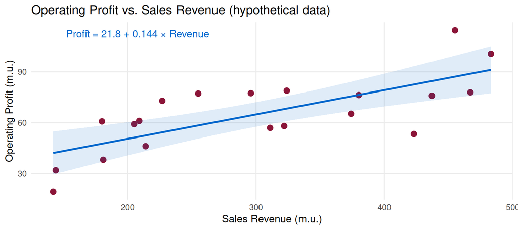

## Properties of OLS Residuals

These **algebraic identities** hold for every OLS fit:

$$\sum_{i=1}^{n} e_i = 0$$

$$\sum_{i=1}^{n} X_i\, e_i = 0$$

$$\sum_{i=1}^{n} \hat{Y}_i\, e_i = 0$$

They are not assumptions — they are guaranteed by the OLS first-order conditions. The residuals automatically sum to zero and are uncorrelated with $X$ and with $\hat{Y}$.

## Estimating the Error Variance

The population error variance $\sigma^2$ is unknown. We estimate it with:

$$\hat{\sigma}^2 = s^2 = \frac{\text{SSR}}{n - 2} = \frac{\displaystyle\sum_{i=1}^{n} e_i^2}{n - 2}$$

We divide by $n - 2$ because estimating $\hat{\beta}_0$ and $\hat{\beta}_1$ **uses up two degrees of freedom**.

The **standard error of the regression** (residual standard error in R):

$$s = \sqrt{\frac{\displaystyle\sum e_i^2}{n-2}}$$

In R: `summary(model)$sigma`

# Lecture Summary

## Key Takeaways — Lecture 8

- **Regression** models the **conditional mean** of $Y$ given $X$ — a statement about averages, not individual values.
- The **SLR model** is $Y_i = \beta_0 + \beta_1 X_i + \varepsilon_i$; the error $\varepsilon_i$ is unavoidable.
- The **Gauss–Markov assumptions** (A1–A5) ensure OLS is BLUE; adding normality (A6) enables exact inference.
- **OLS** chooses $\hat{\beta}_0$ and $\hat{\beta}_1$ to minimise $\sum e_i^2$:
  $$\hat{\beta}_1 = \frac{S_{XY}}{S_{XX}}, \qquad \hat{\beta}_0 = \bar{Y} - \hat{\beta}_1\bar{X}$$
- $\hat{\beta}_1$ is the **marginal effect**: estimated change in mean $Y$ per unit increase in $X$.
- In R: `lm(Y ~ X)` fits the model; `summary()` shows coefficients, standard errors, and $p$-values.

## Looking Ahead

**Lecture 9 — Part II: Goodness of Fit, OLS Properties & Introduction to MLR**

- How well does the line fit? — $R^2$ and the variance decomposition
- Why trust OLS? — The Gauss–Markov theorem
- What if we leave out a relevant variable? — **Omitted Variable Bias**
- Adding more regressors — **Multiple Linear Regression**

**Note**

**Reference:** Newbold Ch. 11.4–11.5, Ch. 12.1–12.3.